# Introduction to ggplot2

Alice Kamau| Ken Mwai | Mark Otiende

5/5/2021

# What is ggplot

- ggplot2 is an R package for producing statistical, or data, graphics.
- Under the tidyverse family of packages
- ggplot2 has an underlying grammar, based on the Grammar of Graphics
- compose graphs by combining independent components.

# How ggplot works

- ggplot2 divides plot into three different fundamental parts:
  - Plot = data + Aesthetics + Geometry
- The principal components of every plot can be defined as follow:
  - **data** is a data frame
  - **Aesthetics** is used to indicate x and y variables. It can also be used to control the color, the size or the shape of points, the height of bars, etc…..
  - **Geometry** defines the type of graphics (histogram, box plot, line plot, density plot, dot plot, ….)

# Load required package

- We begin by loading the required packages. ggplot2 is included in the tidyverse package.

```r
library(tidyverse)
```

- Set the directory

```r
setwd("/Users/akamau/Documents/I-StaR/Course 1/Day3/Presentation/")
```

- Load the data

```r
bw_df <- read.csv("Data/birthweight2.csv")
names(bw_df)
```

```
##  [1] "id"      "matage"  "ht"      "gestwks" "sex"     "bweight" "ethnic"  "lbw"
##  [9] "agegrp"  "lbw2"    "agegrp1"
```

# Why?

- To have an understanding of you data we normally conduct exploratory data analysis (EDA) which can be graphical or numerical
- Primarily EDA is for seeing what the data can tell us before the formal modelling or hypothesis testing task
- Typical graphical techniques used in EDA for one measure:
  - Histogram (one variable continuous),
  - Density plot (one variable continuous),
  - Bar plots (one variable discrete)

# Elements of grammar of graphics

- Data: variables mapped to aesthetic (aes function) features of the graph.
- Geoms: objects/shapes on the graph.
- Stats: statistical transformations that summarize data,(e.g mean, confidence intervals)
- Scales: define which aesthetic values are mapped to data values. Legends and axes display these mappings.
- Coordinate systems: define the plane on which data are mapped on the graphic.
- Faceting: splits the data into subsets to create multiple variations of the same graph (paneling).

# Aesthetic mappings and aes

- Aesthetics are the visually perceivable components of the graph.
- Map variables to aesthetics using the aes function, such as:
  - which variables appear on the x-axis and y-axis.
  - a classification variable to colors
  - a numeric variable to the size of graphical objects

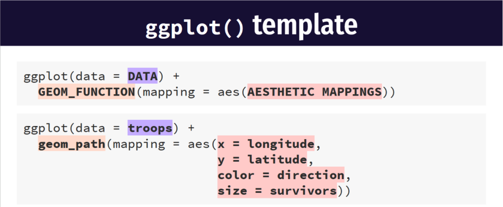

# To build a ggplot

- Use the ggplot() function and bind the plot to a specific data frame using the data argument

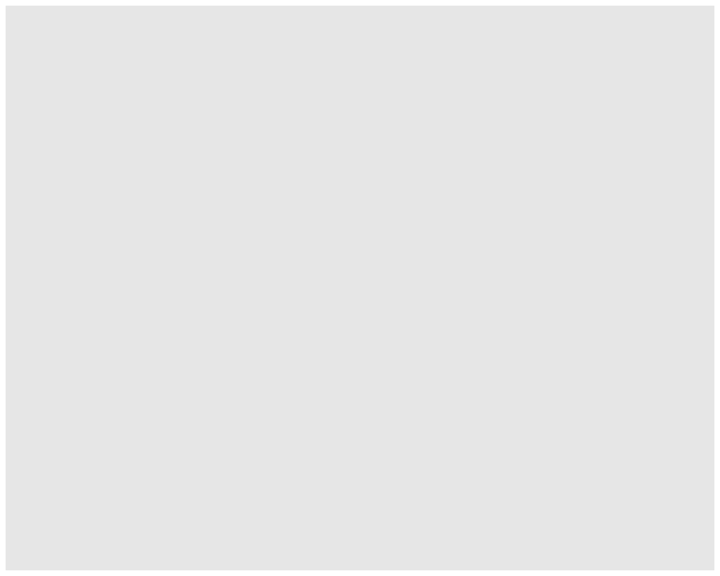

```r
ggplot(data = bw_df)
```

- Define an aesthetic mapping (using the aesthetic (aes) function), by selecting the variables to be plotted and specifying how to present them in the graph, e.g., as x

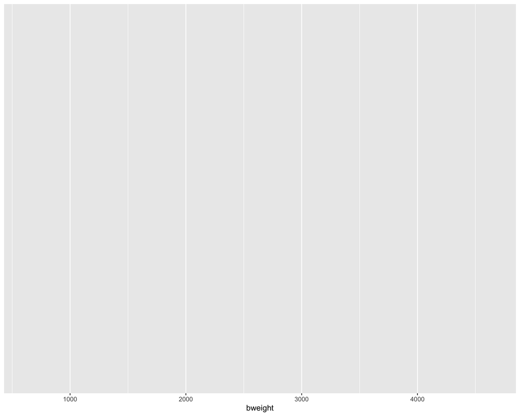

```r
# declare data and x aesthetics, but no aesthetics
ggplot(data = bw_df, aes(x = bweight))
```

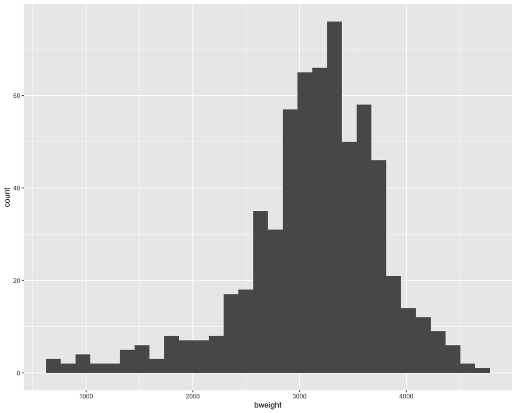

```r
# declare data and x aesthetics,
ggplot(data = bw_df, aes(x = bweight)) + geom_histogram()
```

- The + in the ggplot2 package is particularly useful because it allows you to modify existing ggplot objects.
- The + sign used to add layers must be placed at the end of each line containing a layer.
- If, instead, the + sign is added in the line before the other layer, ggplot2 will not add the new layer and will return an error message.

```r
# This will not add the new layer and will return an error
# message
ggplot(data = bw_df, aes(x = bweight))
+geom_histogram()
```

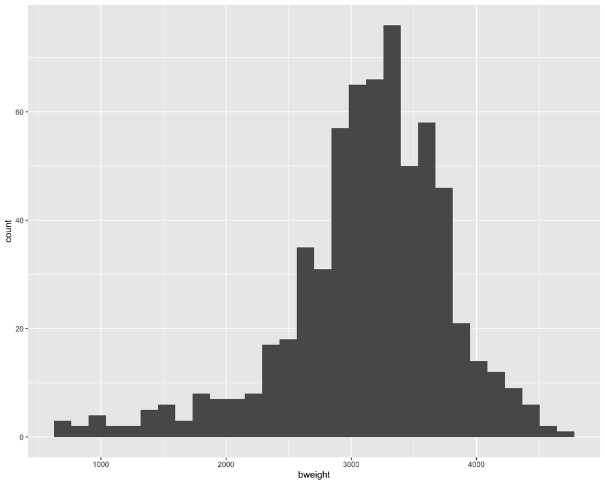

[figure not shown]

```r
# This is the correct syntax for adding layers
ggplot(data = bw_df, aes(x = bweight)) + geom_histogram()
```

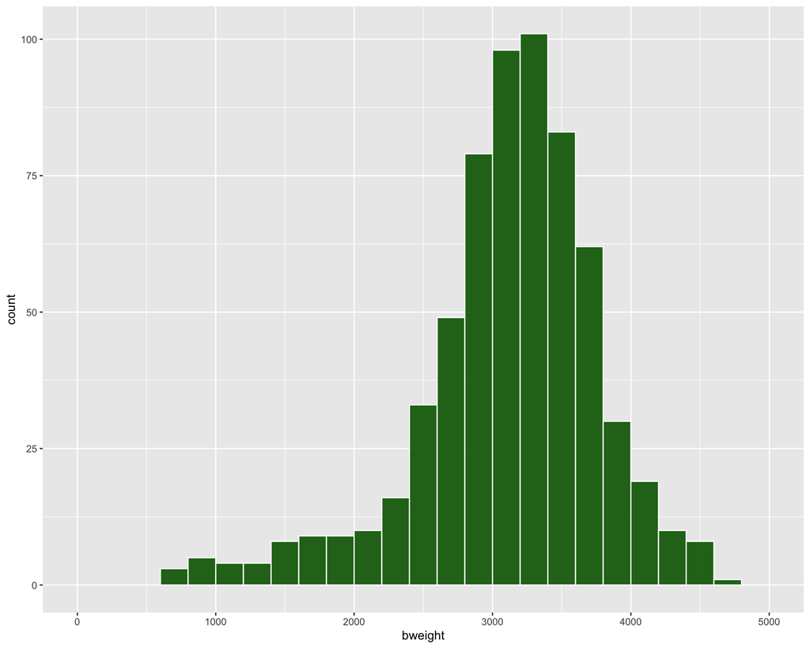

```r
# adding aesthetics to the histogram
ggplot(data = bw_df, aes(x = bweight)) + geom_histogram(breaks = seq(0,
    5000, 200), fill = "dark green", color = "white", alpha = 0.9)
```

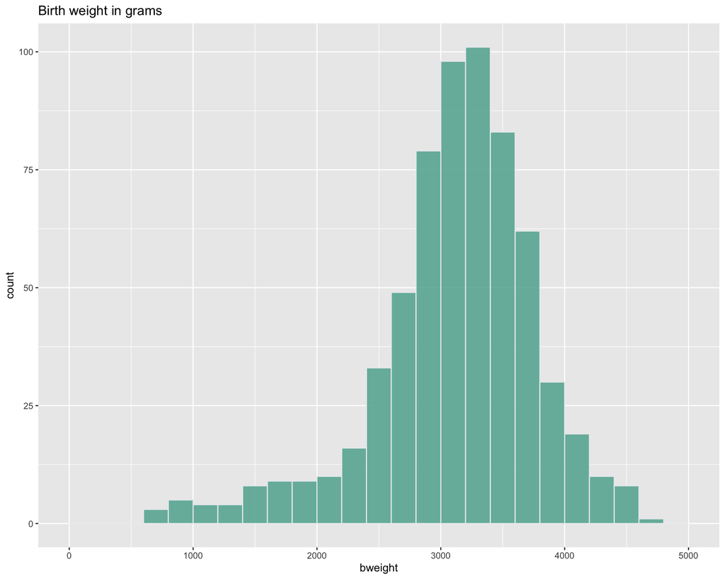

```r
# adding title to the histogram
ggplot(data = bw_df, aes(x = bweight)) + geom_histogram(breaks = seq(0,
    5000, 200), fill = "#69b3a2", color = "#e9ecef", alpha = 0.9) +
    ggtitle("Birth weight in grams")
```

# Density plot

- A density plot is a representation of the distribution of a numeric variable.
- It uses a kernel density estimate to show the probability density function of the variable.

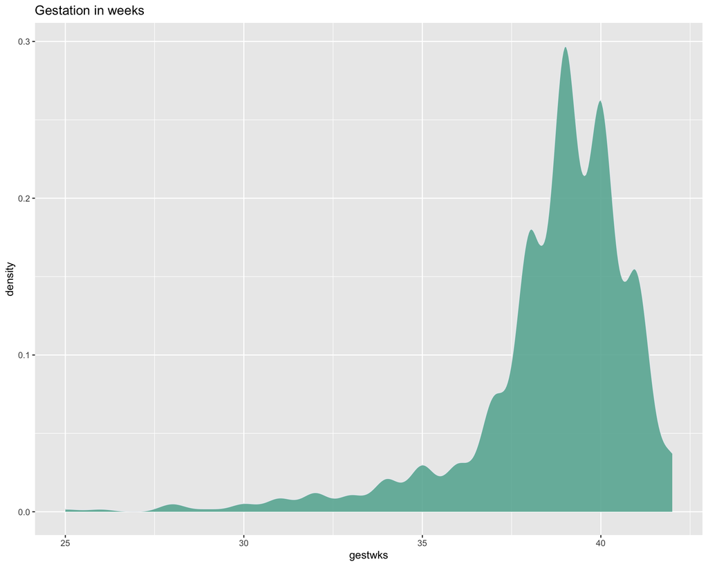

```r
#
ggplot(data = bw_df, aes(x = gestwks)) + geom_density(breaks = seq(0,
    45, 5), fill = "#69b3a2", color = "#e9ecef", alpha = 0.9) +
    ggtitle("Gestation in weeks")
```

# Area plot with ggplot2

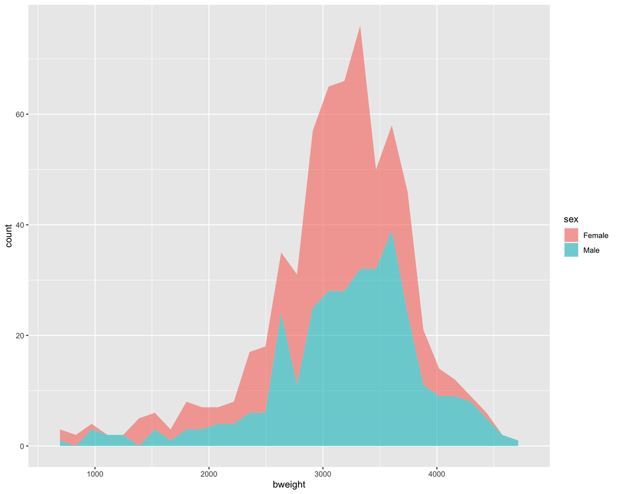

```r
#
ggplot(data = bw_df, aes(x = bweight)) + geom_area(aes(fill = sex),
    stat = "bin", alpha = 0.6)
```

# Integrating the pipe operator with ggplot2

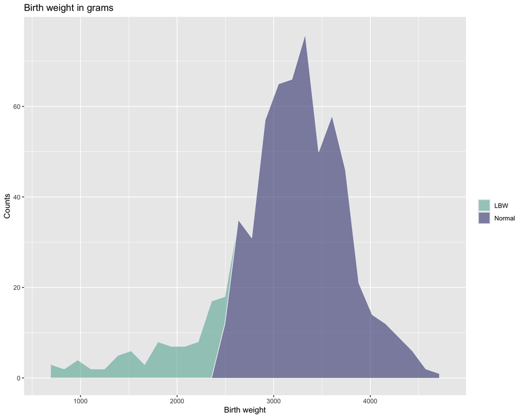

```r
# Make the with fill based on
bw_df %>% mutate(bw_cat = ifelse(bweight < 2500, "LBW", "Normal")) %>%
    ggplot(aes(x = bweight, fill = bw_cat)) + geom_area(stat = "bin",
    color = "#e9ecef", alpha = 0.6) + scale_fill_manual(values = c("#69b3a2",
    "#404080")) + labs(fill = "") + ylab("Counts") + xlab("Birth weight") +
    ggtitle("Birth weight in grams")
```

# Plot for discrete variables

- A bar plot is one of the most common types of graphic for discrete/categorical variables
- Each entity of the categorical variable is represented as a bar and the size of the bar represents its numeric value.

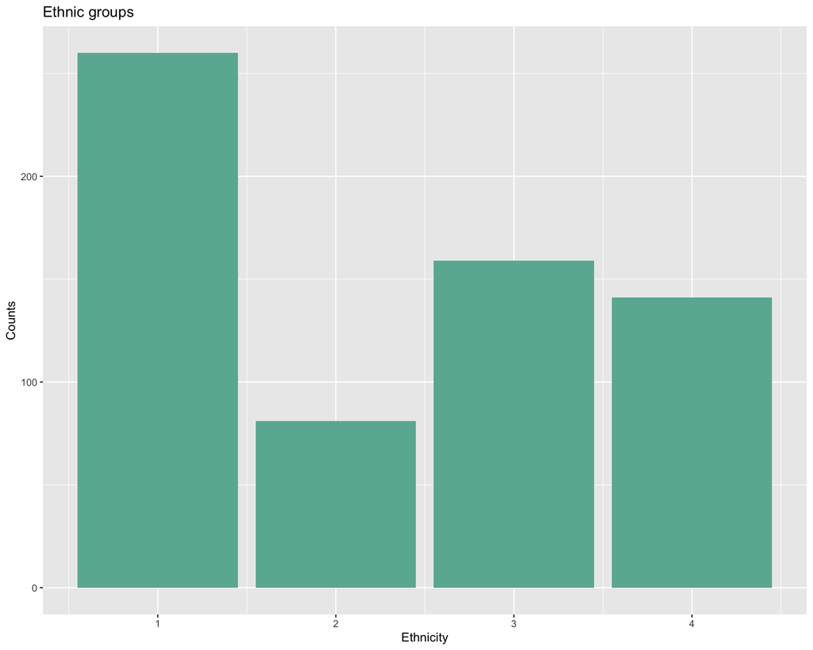

```r
# Bar graphs for categorical variables
ggplot(bw_df, aes(x = ethnic)) + geom_bar(fill = "#69b3a2") +
    ylab("Counts") + xlab("Ethnicity") + ggtitle("Ethnic groups")
```

# ggplot2 themes

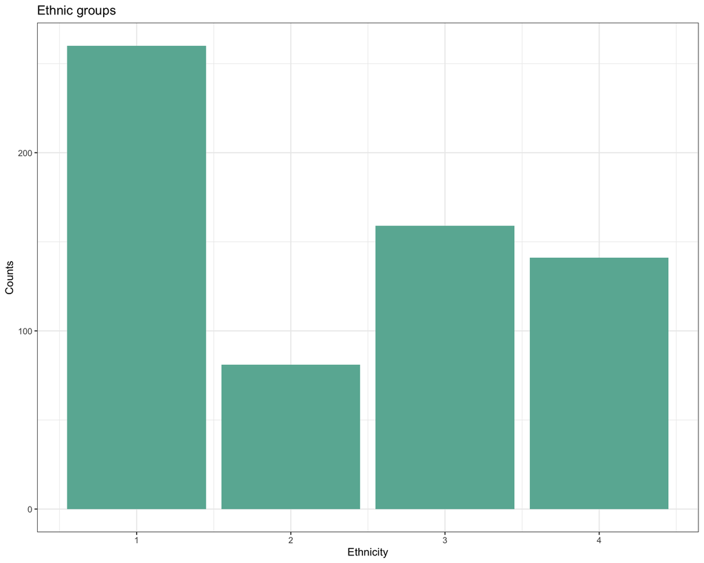

```r
# Bar graphs for categorical variables
ggplot(bw_df, aes(x = ethnic)) + geom_bar(fill = "#69b3a2") +
    ylab("Counts") + xlab("Ethnicity") + ggtitle("Ethnic groups") +
    theme_bw()
```

# Themes

- The complete list of themes is available at https://ggplot2.tidyverse.org/reference/ggtheme.html

### Other types of graphs

http://www.sthda.com/english/wiki/be-awesome-in-ggplot2-a-practical-guide-to-be-highly-effective-r-software-and-data-visualization

# Exporting plots

```r
my_plot <- ggplot(data = bw_df, aes(x = bweight)) + geom_area(aes(fill = sex),
    stat = "bin", alpha = 0.6) + theme_bw()
ggsave("Output/Ethnicity.png", my_plot, width = 15, height = 10)
```